# Notebook

### Web Information Retrieval and Data Mining - Assignment 3

```
Student: Hoogeveen, Dim (1518496)
```

#### Answer 1.1, Baseline (4p)

- Dense network, at least 3 layers, shaped like a pyramid
  - Last layer: 10 nodes, sigmoid.
  - Loss: categorical cross-entropy. Metric: accuracy
- No preprocessing, regularization. Get at least 70% accuracy.
- Explain design decisions. Discuss performance.
  - Does it overfit (large/growing gap between loss and val_loss)?

[output not shown]

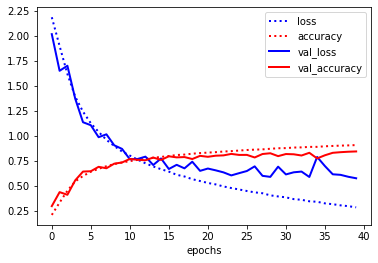

```
Model: "sequential_2"
_________________________________________________________________
Layer (type)                 Output Shape              Param #
=================================================================
reshape_2 (Reshape)          (None, 3072)              0
_________________________________________________________________
dense_4 (Dense)              (None, 2318)              7123214
_________________________________________________________________
dense_5 (Dense)              (None, 1174)              2722506
_________________________________________________________________
dense_6 (Dense)              (None, 595)               699125
_________________________________________________________________
dense_7 (Dense)              (None, 301)               179396
_________________________________________________________________
dense_8 (Dense)              (None, 153)               46206
_________________________________________________________________
dense_9 (Dense)              (None, 78)                12012
_________________________________________________________________
dense_10 (Dense)             (None, 40)                3160
_________________________________________________________________
dense_11 (Dense)             (None, 20)                820
_________________________________________________________________
dense_12 (Dense)             (None, 10)                210
=================================================================
Total params: 10,786,649
Trainable params: 10,786,649
Non-trainable params: 0
_________________________________________________________________
None
def build_model_1_1():
    model = models.Sequential()
    model.add(layers.Reshape((3072,), input_shape=(32,32,3)))

    for i in range(n_hidden_layers):
        model.add(layers.Dense(n_nodes_hidden_layer[i], activation='relu'))

    # model.add(layers.Dense(2048, activation='relu')) The next 4 for overfitting 89/84 with 40 epoch
    # model.add(layers.Dense(512, activation='relu'))
    # model.add(layers.Dense(128, activation='relu'))
    # model.add(layers.Dense(32, activation='relu'))

    model.add(layers.Dense(10, activation='softmax'))
    model.compile(optimizer = SGD(nesterov=True),
                    loss='categorical_crossentropy',
                    metrics=['accuracy'])
    return model
```

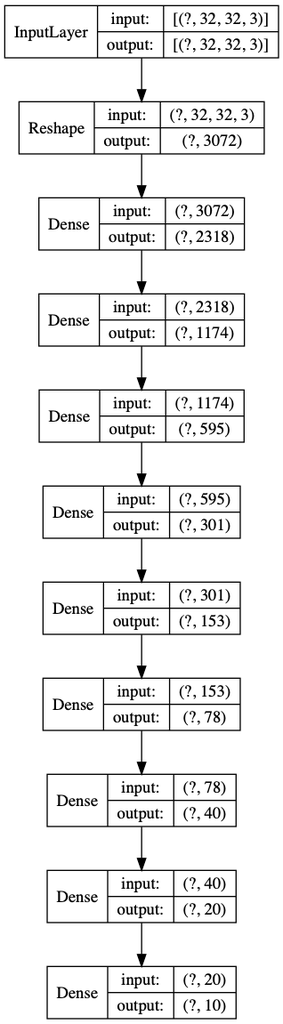

#### Answer 1.2, Preprocess (2p)

- Convert images to greyscale, other preprocessing optional.
  - Input shape should be (32,32,1)
- Explain design decisions. Is it better? Why (not)?
  - Color information is likely not so useful for classification. Greyscale makes the network smaller, less parameters to learn, less likely to overfit.

[output not shown]

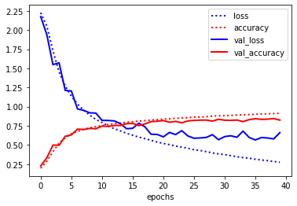

```
Model: "sequential_1"
_________________________________________________________________
Layer (type)                 Output Shape              Param #
=================================================================
reshape_1 (Reshape)          (None, 1024)              0
_________________________________________________________________
dense_9 (Dense)              (None, 2318)              2375950
_________________________________________________________________
dense_10 (Dense)             (None, 1174)              2722506
_________________________________________________________________
dense_11 (Dense)             (None, 595)               699125
_________________________________________________________________
dense_12 (Dense)             (None, 301)               179396
_________________________________________________________________
dense_13 (Dense)             (None, 153)               46206
_________________________________________________________________
dense_14 (Dense)             (None, 78)                12012
_________________________________________________________________
dense_15 (Dense)             (None, 40)                3160
_________________________________________________________________
dense_16 (Dense)             (None, 20)                820
_________________________________________________________________
dense_17 (Dense)             (None, 10)                210
=================================================================
Total params: 6,039,385
Trainable params: 6,039,385
Non-trainable params: 0
_________________________________________________________________
None
def build_model_1_2():
    model = models.Sequential()
    model.add(layers.Reshape((1024,), input_shape=(32,32,1)))
    for i in range(n_hidden_layers):
            model.add(layers.Dense(n_nodes_hidden_layer[i], activation='relu'))
    model.add(layers.Dense(10, activation='softmax'))
    model.compile(optimizer= SGD(nesterov=True),
                    loss='categorical_crossentropy',
                    metrics=['accuracy'])
    return model
```

#### Answer 1.3, Tune (4p)

- Regularize the model. What works best?
  - Should consider batch normalization, dropout, l1/l2 regularization (or Nesterov)
- Tune other hyperparameters (e.g. learning rate, batch size,...) as you see fit.
  - At least consider tuning learning rate, ideally also momentum, decay, other optimizers
- Explain your findings and final design decisions. Discuss the results.
  - Should be better, at least it shouldn't overfit

[output not shown]

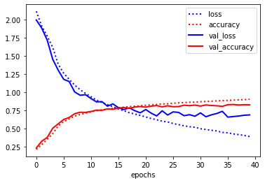

```
def build_model_1_3():
    model = models.Sequential()
    model.add(layers.Reshape((1024,), input_shape=(32,32,1)))

    for i in range(n_hidden_layers):
        if i == (n_hidden_layers - 4):
            model.add(layers.Dropout(0.1))
        elif i == (n_hidden_layers - 3):
            model.add(layers.Dropout(0.2))
        elif i == (n_hidden_layers - 2):
            model.add(layers.Dropout(0.4))

        model.add(layers.Dense(n_nodes_hidden_layer[i], activation='relu'
                            #   ,kernel_regularizer=regularizers.l1_l2(l1=2e-4, l2=1e-3)))
                              ,activity_regularizer=regularizers.l1_l2(l1=1e-4, l2=1e-3)))
                            #   ,bias_regularizer=regularizers.l2(0.8)))


    model.add(layers.Dense(10, activation='softmax'))
    model.compile(optimizer= SGD(learning_rate=1e-2, momentum=0.9, nesterov=True, decay=1e-2/epochs),
                    loss='categorical_crossentropy',
                    metrics=['accuracy'])
    return model
```

#### Answer 2.1, ConvNet (7p)

- Build a sequential ConvNet, get at least 90% accuracy.
  - Conv2D layers, input shape (32,32,1)
  - Consider using blocks of Conv2D layers with maxpooling in between
  - Use zero-padding in Conv2D layers because the images are small
  - At least one dense hidden layer and dense output layer (sigmoid)
  - Consider adding batch normalization, dropout
  - Consider small dropout rates in beginning, larger dropout rates later in network
  - Consider other optimizers and tuning learning rate, momentum,...
- Explain what you did and why (800 chars). Is it working well?
  - Should be quite elaborate and sensible

[output not shown]

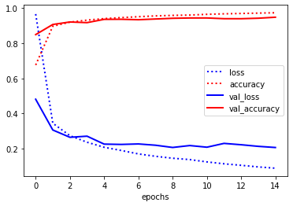

```
Model: "sequential_5"
_________________________________________________________________
Layer (type)                 Output Shape              Param #
=================================================================
conv2d (Conv2D)              (None, 32, 32, 16)        416
_________________________________________________________________
batch_normalization (BatchNo (None, 32, 32, 16)        64
_________________________________________________________________
conv2d_1 (Conv2D)            (None, 32, 32, 32)        25120
_________________________________________________________________
batch_normalization_1 (Batch (None, 32, 32, 32)        128
_________________________________________________________________
conv2d_2 (Conv2D)            (None, 32, 32, 32)        25632
_________________________________________________________________
batch_normalization_2 (Batch (None, 32, 32, 32)        128
_________________________________________________________________
dropout_2 (Dropout)          (None, 32, 32, 32)        0
_________________________________________________________________
conv2d_3 (Conv2D)            (None, 32, 32, 64)        18496
_________________________________________________________________
max_pooling2d (MaxPooling2D) (None, 16, 16, 64)        0
_________________________________________________________________
conv2d_4 (Conv2D)            (None, 16, 16, 64)        102464
_________________________________________________________________
batch_normalization_3 (Batch (None, 16, 16, 64)        256
_________________________________________________________________
conv2d_5 (Conv2D)            (None, 16, 16, 64)        36928
_________________________________________________________________
max_pooling2d_1 (MaxPooling2 (None, 8, 8, 64)          0
_________________________________________________________________
dropout_3 (Dropout)          (None, 8, 8, 64)          0
_________________________________________________________________
conv2d_6 (Conv2D)            (None, 8, 8, 128)         204928
_________________________________________________________________
batch_normalization_4 (Batch (None, 8, 8, 128)         512
_________________________________________________________________
conv2d_7 (Conv2D)            (None, 8, 8, 128)         147584
_________________________________________________________________
batch_normalization_5 (Batch (None, 8, 8, 128)         512
_________________________________________________________________
```

[output cut: 43 more lines]

```
    model.add(BatchNormalization())

    model.add(MaxPooling2D(pool_size=(2, 2)))
    model.add(Dropout(0.4))

    model.add(Flatten())
    model.add(Dense(128, activation='relu'))
    model.add(Dense(64, activation='relu'))

    model.add(layers.Dense(10, activation='softmax'))

    model.compile(optimizer='adam',
              loss='categorical_crossentropy',
              metrics=['accuracy'])
    return model
```

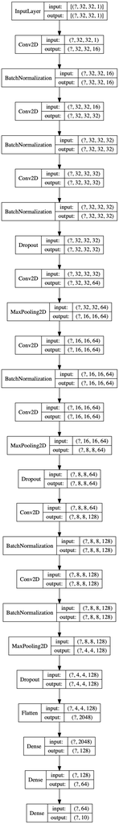

#### Answer 2.2, Data Augmentation (3p)

- Augment the preprocessed training data.
  - Use small variations (small shifts up-down, left-right) of flips becasue the images are small
  - Large shifts and rotations distort the image too much
- Explain what you did and why. Discuss the performance of the model.

[output not shown]

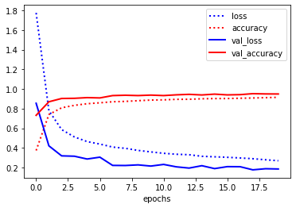

```
train_datagen = ImageDataGenerator(
    width_shift_range=[0, 16], # amount of pixels shift to right; 32 pixels present. Most left digit is actual label, so shift to right.
    # height_shift_range=0.1,
    # horizontal_flip=True,
    # preprocessing_function=preprocessing
    # rotation_range= 15,
    # zoom_range=0.2
    )
```

#### Answer 3.1, Misclassifications (2p)

[output not shown]

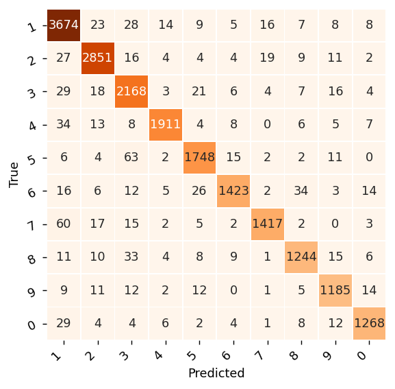

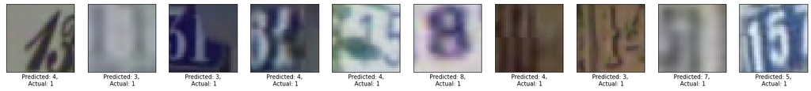

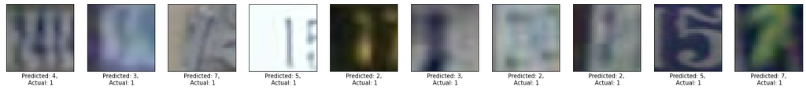

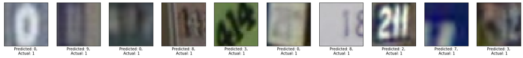

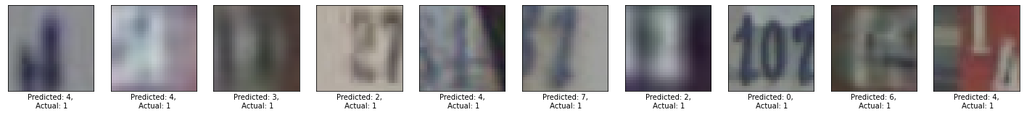

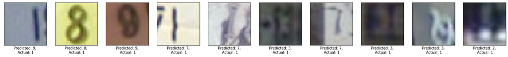

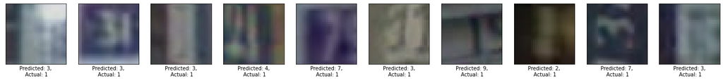

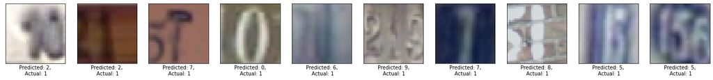

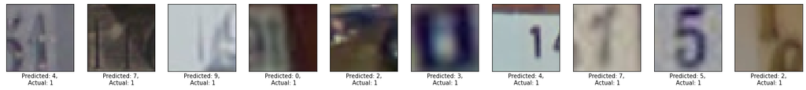

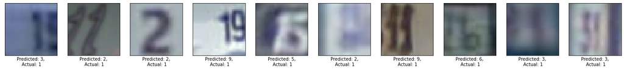

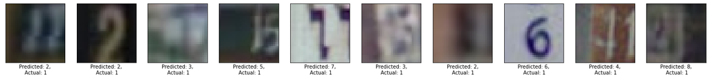

#### Answer 3.2, Activations (4p)

- Retrieve and visualize the activations for one example
- For every filter for different convolutional layers (at different depths in the network).
- Give an explanation. Is your model indeed learning something useful?
  - Should detect edges etc in first layers, higher-order object (e.g. interesting regions) in deeper layers.

[output not shown]

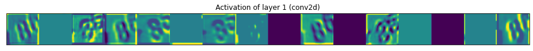

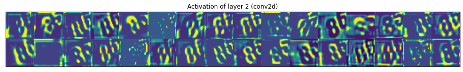

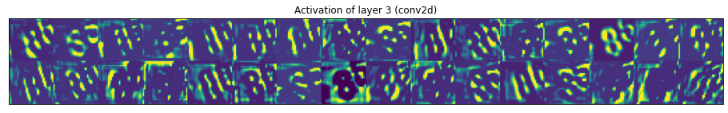

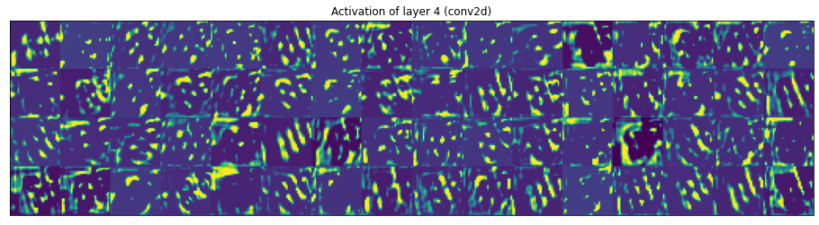

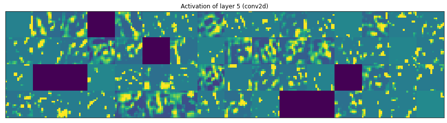

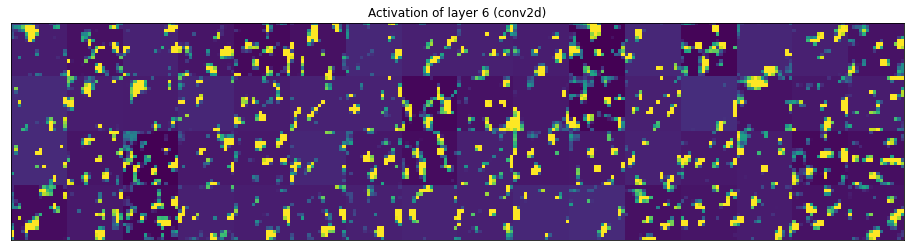

#### Answer 3.3, Class activation map (4p)

- Show a class activation map for your last convolutional layer
- Superimpose the activation map over the image, or plot side by side
  - Should make sense, detect interesting regions to classify the number

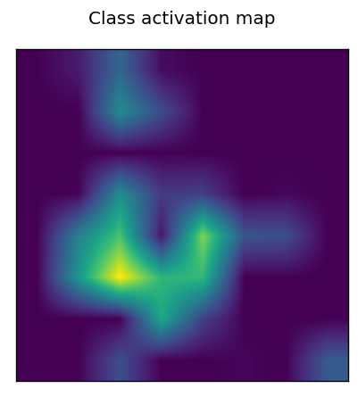

```
def plot_activation_map():
    img_tensor = preprocessing(X_test)[0]
    img_tensor = np.expand_dims(img_tensor, axis=0)
    conv_layer = [layer for layer in model_2_2.layers if 'conv2d' in layer.name][-1]
    heatmap_model = models.Model([model_2_2.inputs], [conv_layer.output, model_2_2.output])

    with tf.GradientTape() as tape:
        conv_output, predictions = heatmap_model(img_tensor)
        loss = predictions[:, np.argmax(predictions[0])]
        grads = tape.gradient(loss, conv_output)
        pooled_grads = K.mean(grads, axis=(0, 1, 2))

    heatmap = tf.reduce_mean(tf.multiply(pooled_grads, conv_output), axis=-1)[0]

    # plot
    heatmap = np.maximum(heatmap, 0)
    heatmap /= np.max(heatmap)
    heatmap = cv2.resize(heatmap, (fig_size, fig_size))

    plt.rcParams['figure.dpi'] = 120
    plt.matshow(heatmap)
    plt.title('Class activation map')
    plt.xticks([])
    plt.yticks([])
    plt.show()

    return heatmap
```

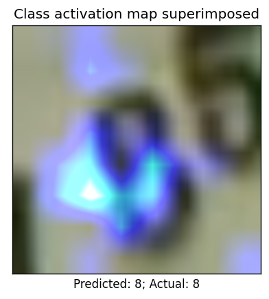

#### Answer 4.1, Fast feature extraction (5p)

- Import the VGG16 model, pretrained on ImageNet
- Freeze convolutional base, adds a dense layer
- Consider unfreezing the last few convolutional layers and evaluate whether that works better
  - Check if they do. It is very likely to help.
- Discuss the observed performance
  - Should get around 80% accuracy

[output not shown]

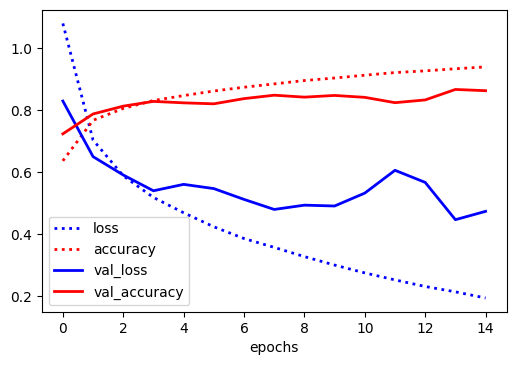

```
Model: "model_2"
_________________________________________________________________
Layer (type)                 Output Shape              Param #
=================================================================
input_3 (InputLayer)         [(None, 32, 32, 3)]       0
_________________________________________________________________
block1_conv1 (Conv2D)        (None, 32, 32, 64)        1792
_________________________________________________________________
block1_conv2 (Conv2D)        (None, 32, 32, 64)        36928
_________________________________________________________________
block1_pool (MaxPooling2D)   (None, 16, 16, 64)        0
_________________________________________________________________
block2_conv1 (Conv2D)        (None, 16, 16, 128)       73856
_________________________________________________________________
block2_conv2 (Conv2D)        (None, 16, 16, 128)       147584
_________________________________________________________________
block2_pool (MaxPooling2D)   (None, 8, 8, 128)         0
_________________________________________________________________
block3_conv1 (Conv2D)        (None, 8, 8, 256)         295168
_________________________________________________________________
block3_conv2 (Conv2D)        (None, 8, 8, 256)         590080
_________________________________________________________________
block3_conv3 (Conv2D)        (None, 8, 8, 256)         590080
_________________________________________________________________
block3_pool (MaxPooling2D)   (None, 4, 4, 256)         0
_________________________________________________________________
block4_conv1 (Conv2D)        (None, 4, 4, 512)         1180160
_________________________________________________________________
block4_conv2 (Conv2D)        (None, 4, 4, 512)         2359808
_________________________________________________________________
block4_conv3 (Conv2D)        (None, 4, 4, 512)         2359808
_________________________________________________________________
block4_pool (MaxPooling2D)   (None, 2, 2, 512)         0
_________________________________________________________________
block5_conv1 (Conv2D)        (None, 2, 2, 512)         2359808
_________________________________________________________________
block5_conv2 (Conv2D)        (None, 2, 2, 512)         2359808
_________________________________________________________________
block5_conv3 (Conv2D)        (None, 2, 2, 512)         2359808
_________________________________________________________________
```

[output cut: 21 more lines]

```
        if layer.name in unfreeze_layers:
            layer.trainable = True
        else:
            layer.trainable = False

    add_model.add(layers.Flatten(input_shape=base_model.output_shape[1:]))
    add_model.add(layers.Dense(128, activation='relu'))
    add_model.add(layers.Dense(10, activation='softmax'))

    model = models.Model(inputs=base_model.input, outputs=add_model(base_model.output))

    model.compile(optimizer=optimizers.RMSprop(learning_rate=2e-5),
            loss='categorical_crossentropy',
            metrics=['accuracy'])
    return model
```

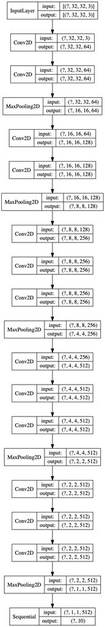

#### Answer 4.2, Embeddings (5p)

- Generate embeddings with the trained convolutional part of model_4_1 (without the dense layer)
- Embed the training and test data and store them to disk
- Build and evaluate a pipeline on the embedded data
  - Check if pipeline makes sense (e.g. use models that can handle many dimensions)
- Describe what you did and what you observed (max 800 chars).
  - Consider different models, preprocessing, tuning, etc.
  - Check performance (see original Submission.html) when in doubt. We did not run all the evaluations because it takes too long, and the output is ill-defined.

[output not shown]

```
Running time: 19.00 seconds
Last modified: May 26, 2020
scikit-learn version: 0.23.1
```